# Exercise #3

Fortgeschrittene Statistische Software für NF

yassmine jenayh (12358722)  
2025-06-05

## General Remarks

- You can submit your solutions in teams of up to 3 students.
- Include all your team-member’s names and student numbers (Matrikelnummern) in the `authors` field.
- Please use the exercise template document to work on and submit your results.
- Use a level 2 heading for each new exercise and answer each subtask next to its bullet points or use a new level 3 heading if you want.
- Always render the R code for your solutions (`echo=TRUE`) and make sure to include the resulting data in your rendered document.
  - Make sure to not print more than 10 rows of data (unless specifically instructed to).
- Always submit both the rendered document(s) as well as your source Rmarkdown or Quarto document. Submit the files separately on moodle, **not** as a zip archive.
- Submission format is HTML. Other formats will lead to a deduction of points.

## Exercise 1: Initializing git (4 Points)

For this whole exercise sheet we will be tracking all our changes to it in git.

1. Start by initializing a new R project with git support, called `2025-exeRcise-sheet-3`. If you forgot how to do this, you can follow this [guide](https://malikaihle.github.io/Introduction-RStudio-Git-GitHub/rstudio_project.html).
2. Commit the files generated by Rstudio.
3. For all of the following tasks in this exercise sheet we ask you to always commit your changes after finishing each subtask e.g. create a commit after task *1d*, *1e* etc.

> Note: This applies only to answers that have text or code as their answer. If you complete tasks in a different order or forget to commit one, this is no problem. If you change your answers you can just create multiple commits to track the changes.
4. Name 2 strengths and 2 weaknesses of git. (Don’t forget to create a commit after this answer, see *1c*)

   Strengths of Git:

   1-Every developer has a full copy of the repository so no internet needed

   2-merge code safely with minimal risk

   Weaknesses of Git:

   1-some concepts are confusing at first

   2-it isn’t optimized for handling large files
5. Knit this exercise sheet. Some new files will automatically be generated when knitting the sheet e.g. the HTML page. Ignore these files, as we only want to track the source files themselves. You can, but don’t need to create a `.gitignore` file. Just do not commit these files manually.

## Exercise 2: Putting your Repository on GitHub (3 Points)

For this task you will upload your solution to GitHub.

1. Create a new repository on GitHub in your account named `exeRcise-sheet-3`. Make sure you create a **public repository** so we are able to see it for grading. Add the link to the repository below:

   https://github.com/yassmine2001/exeRcise-sheet-3.git
2. Push your code to this new repository by copying and executing the snippet on github listed under `…or push an existing repository from the command line`.
3. Regularly push your latest changes to GitHub again and especially do so when you are finished with this sheet.

## Exercise 3: Pixar Films (4 Points)

Download the `pixar_films` and `public_response` datasets from the GitHub repository and track them in git.

Link: https://github.com/rfordatascience/tidytuesday/tree/main/data/2025/2025-03-11

For small datasets like these adding them to git is not a problem.

1. Load the `pixar_films` dataset into R. Clean the dataset by removing films without a title. Inspect the variable `film_rating`. What are the possible values and what do they mean? Create a factor variable for the film rating. Why is this appropriate?

```r
library(tidyverse)
pixar_films <- read_csv("C:/Users/yassminejn/Downloads/pixar_films.csv")
pixar_films <- pixar_films %>%
  filter(!is.na(film), film != "")
pixar_films
```

```
# A tibble: 26 × 5
   number film            release_date run_time film_rating
    <dbl> <chr>           <date>          <dbl> <chr>
 1      1 Toy Story       1995-11-22         81 G
 2      2 A Bug's Life    1998-11-25         95 G
 3      3 Toy Story 2     1999-11-24         92 G
 4      4 Monsters, Inc.  2001-11-02         92 G
 5      5 Finding Nemo    2003-05-30        100 G
 6      6 The Incredibles 2004-11-05        115 PG
 7      7 Cars            2006-06-09        117 G
 8      8 Ratatouille     2007-06-29        111 G
 9      9 WALL-E          2008-06-27         98 G
10     10 Up              2009-05-29         96 PG
# ℹ 16 more rows
```

```r
unique(pixar_films$film_rating)
```

```
[1] "G"   "PG"  "N/A"
```

```r
pixar_films <- pixar_films %>%
  mutate(film_rating_factor = factor(film_rating))
```

The variable film_rating includes the values : “G”, “PG”, and “N/A”.

G: General audiences: Suitable for all ages

PG: Parental guidance suggested

N/A: Not Available: the film has no official rating listed in the dataset

a factor represents a set of categorical values with specific meanings. Using it makes it easier to group, summarize, and plot this data appropriately in R.

2. Inspect the film titles manually. Which films form a film series? A film series can be identified by a common word in the titles of the films, often in conjunction with a number in the title, e.g. “Despicable Me” and “Despicable Me 2”. Create a dataframe which displays a list of the different series with the titles of the films and how many films belong to the series. Output the dataframe.

   ```r
   unique(pixar_films$film)
   ```

   ```
    [1] "Toy Story"           "A Bug's Life"        "Toy Story 2"
    [4] "Monsters, Inc."      "Finding Nemo"        "The Incredibles"
    [7] "Cars"                "Ratatouille"         "WALL-E"
   [10] "Up"                  "Toy Story 3"         "Cars 2"
   [13] "Brave"               "Monsters University" "Inside Out"
   [16] "The Good Dinosaur"   "Finding Dory"        "Cars 3"
   [19] "Coco"                "Incredibles 2"       "Toy Story 4"
   [22] "Onward"              "Soul"                "Luca"
   [25] "Turning Red"         "Lightyear"
   ```

   ```r
   library(dplyr)
   library(stringr)
   pixar_films <- pixar_films %>%
     mutate(series = case_when(
   str_detect(film, "Toy Story") ~ "Toy Story",
   str_detect(film, "Cars") ~ "Cars",
   str_detect(film, "Finding") ~ "Finding",
   str_detect(film, "Incredibles") ~ "Incredibles",
   str_detect(film, "Monsters") ~ "Monsters",
   TRUE ~ NA_character_
     ))
   series_summary <- pixar_films %>%
     filter(!is.na(series)) %>%
     group_by(series) %>%
     summarise(
   titles = paste(film, collapse = "; "),
   count = n(),
   .groups = "drop"
     )
   series_summary
   ```

   ```
   # A tibble: 5 × 3
     series      titles                                           count
     <chr>       <chr>                                            <int>
   1 Cars        Cars; Cars 2; Cars 3                                 3
   2 Finding     Finding Nemo; Finding Dory                           2
   3 Incredibles The Incredibles; Incredibles 2                       2
   4 Monsters    Monsters, Inc.; Monsters University                  2
   5 Toy Story   Toy Story; Toy Story 2; Toy Story 3; Toy Story 4     4
   ```

3. Load the `public_response` dataframe into R. Convert the `cinema_score` variable into a factor while ensuring the factor levels are defined in ascending order, from the lowest to the highest score. Combine `public_response` with the `pixar_films` dataset using an appropriate merge variable.

   ```r
   public_response <- read_csv("C:/Users/yassminejn/Downloads/public_response.csv")
   unique(public_response$cinema_score)
   ```

   ```
   [1] "A"  "A+" "A-" NA
   ```

   ```r
   cinema_levels <- c("A-", "A", "A+")
   public_response <- public_response %>%
     mutate(cinema_score = factor(cinema_score, levels = cinema_levels, ordered = TRUE))
   sort(public_response$cinema_score)
   ```

   ```
    [1] A- A- A  A  A  A  A  A  A  A  A  A  A  A  A  A+ A+ A+ A+ A+ A+ A+
   Levels: A- < A < A+
   ```

4. Choose one of the variables representing the public response and create a bar plot for the films belonging to a series. Here are the details of the plot:
   - The film series are represented on the x-axis.
   - Your chosen public response variable is displayed on the y-axis.
   - Each film in the series is represented as a separate bar. Bars are grouped by film under their respective series on the x-axis. Order the bars within a series according to the release date of the films.
   - A title and axis labels for context.

   What do you notice when comparing the scores of the films in a series? Do you see any patterns?

   ```r
   library(dplyr)
   films_with_scores <- inner_join(pixar_films, public_response, by = "film")
   films_with_scores
   ```

   ```
   # A tibble: 24 × 11
      number film    release_date run_time film_rating film_rating_factor
       <dbl> <chr>   <date>          <dbl> <chr>       <fct>
    1      1 Toy St… 1995-11-22         81 G           G
    2      2 A Bug'… 1998-11-25         95 G           G
    3      3 Toy St… 1999-11-24         92 G           G
    4      4 Monste… 2001-11-02         92 G           G
    5      5 Findin… 2003-05-30        100 G           G
    6      6 The In… 2004-11-05        115 PG          PG
    7      7 Cars    2006-06-09        117 G           G
    8      8 Ratato… 2007-06-29        111 G           G
    9      9 WALL-E  2008-06-27         98 G           G
   10     10 Up      2009-05-29         96 PG          PG
   # ℹ 14 more rows
   # ℹ 5 more variables: series <chr>, rotten_tomatoes <dbl>,
   #   metacritic <dbl>, cinema_score <ord>, critics_choice <dbl>
   ```

   ```r
   series_films <- films_with_scores %>%
     filter(!is.na(series), !is.na(critics_choice))
   series_films
   ```

   ```
   # A tibble: 12 × 11
      number film    release_date run_time film_rating film_rating_factor
       <dbl> <chr>   <date>          <dbl> <chr>       <fct>
    1      3 Toy St… 1999-11-24         92 G           G
    2      4 Monste… 2001-11-02         92 G           G
    3      5 Findin… 2003-05-30        100 G           G
    4      6 The In… 2004-11-05        115 PG          PG
    5      7 Cars    2006-06-09        117 G           G
    6     11 Toy St… 2010-06-18        103 G           G
    7     12 Cars 2  2011-06-24        106 G           G
    8     14 Monste… 2013-06-21        104 G           G
    9     17 Findin… 2016-06-17         97 PG          PG
   10     18 Cars 3  2017-06-16        102 G           G
   11     20 Incred… 2018-06-15        118 PG          PG
   12     21 Toy St… 2019-06-21        100 G           G
   # ℹ 5 more variables: series <chr>, rotten_tomatoes <dbl>,
   #   metacritic <dbl>, cinema_score <ord>, critics_choice <dbl>
   ```

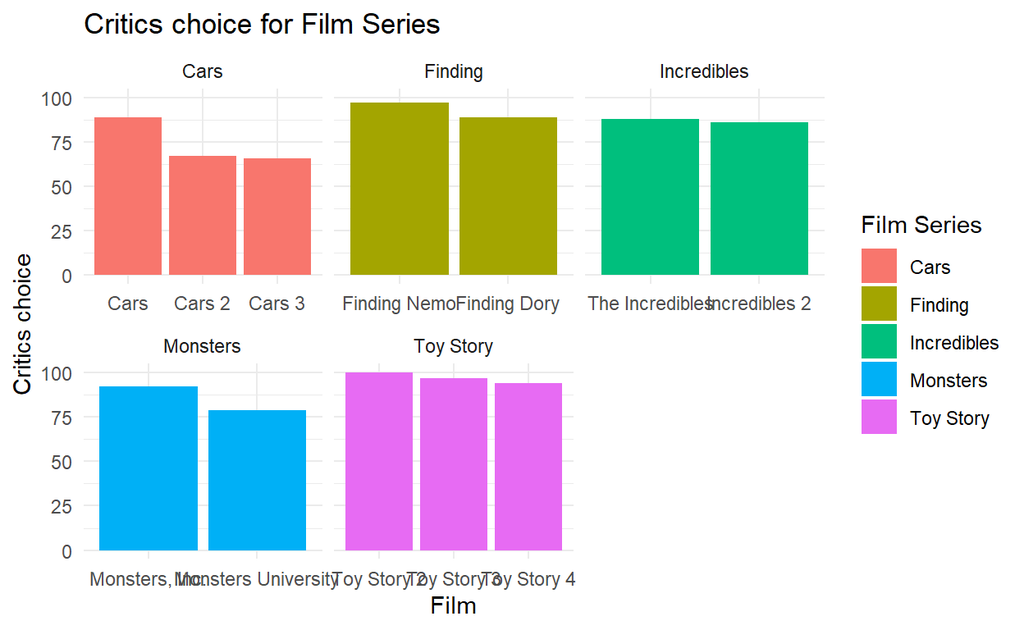

   ```r
   library(ggplot2)
   ggplot(series_films, aes(x = reorder(film, release_date), y = critics_choice, fill = series)) +
     geom_col() +
     facet_wrap(~ series, scales = "free_x") +
     labs(
   title = "Critics choice for Film Series",
   x = "Film",
   y = "Critics choice",
   fill = "Film Series"
     ) +
     theme_minimal()
   ```

   by comparing the critic scores of films within the same series, I noticed that the scores tend to be consistent . However, a common pattern is that the first released film in a series often receives the highest critic score

## Exercise 4: Open Analysis (4 points)

This exercise is a bit more open-ended. You can choose any dataset from [Our World in Data](https://ourworldindata.org/) and analyze it, while determining the research question yourself.

1. Go to https://github.com/owid/owid-datasets/tree/master/datasets and choose a dataset that interests you. You can have a look at https://ourworldindata.org/ to gather some inspiration.
2. Download the dataset and track it in git.
3. Put the name / title of the dataset and a link to it below.

   Dataset Name: Adult obesity by region - FAO (2017)

   Link: https://github.com/owid/owid-datasets/blob/master/datasets/Adult%20obesity%20by%20region%20-%20FAO%20(2017)/Adult%20obesity%20by%20region%20-%20FAO%20(2017).csv
4. Come up with a (research) question you want to answer with the data and briefly explain why you believe this is an interesting question within one sentence. It should be a question that can be answered with the dataset and using R.

   Research Question:

Which world regions have experienced the highest increases in adult obesity rates from 1975 to 2014?

This question is important because identifying regional trends in obesity can help shape more effective global and regional public health policies.

5. Use R to answer your chosen question. Please limit your analysis to the functions and techniques we have covered so far in the course. You are **not expected** to use advanced statistical models or external packages which haven’t been introduced.

   ```r
   obesity <- read.csv("Adult obesity by region - FAO (2017).csv")
   str(obesity)
   ```

   ```
   'data.frame':   240 obs. of  3 variables:
    $ Entity                                                      : chr  "Africa" "Africa" "Africa" "Africa" ...
    $ Year                                                        : int  1975 1976 1977 1978 1979 1980 1981 1982 1983 1984 ...
    $ Prevalence.of.obesity.in.adults..18..years.old...FAO..2017..: num  3 3.1 3.2 3.3 3.5 3.6 3.7 3.8 4 4.1 ...
   ```

   ```r
   head(obesity)
   ```

   ```
     Entity Year
   1 Africa 1975
   2 Africa 1976
   3 Africa 1977
   4 Africa 1978
   5 Africa 1979
   6 Africa 1980
     Prevalence.of.obesity.in.adults..18..years.old...FAO..2017..
   1                                                          3.0
   2                                                          3.1
   3                                                          3.2
   4                                                          3.3
   5                                                          3.5
   6                                                          3.6
   ```

   ```r
   obesity_change <- obesity %>%
     select(Entity, Year, Obesity = Prevalence.of.obesity.in.adults..18..years.old...FAO..2017..) %>%
     pivot_wider(names_from = Year, values_from = Obesity) %>%
     mutate(Change = `2014` - `1975`) %>%
     arrange(desc(Change))
      obesity_change
   ```

   ```
   # A tibble: 6 × 42
     Entity       `1975` `1976` `1977` `1978` `1979` `1980` `1981` `1982`
     <chr>         <dbl>  <dbl>  <dbl>  <dbl>  <dbl>  <dbl>  <dbl>  <dbl>
   1 Oceania         9.6    9.8   10.1   10.3   10.6   10.9   11.2   11.4
   2 North Ameri…   11.1   11.4   11.7   12     12.3   12.6   12.9   13.2
   3 Latin Ameri…    6.8    7.1    7.3    7.6    7.9    8.1    8.4    8.7
   4 World           4.5    4.6    4.7    4.8    4.9    5      5.1    5.3
   5 Africa          3      3.1    3.2    3.3    3.5    3.6    3.7    3.8
   6 Asia            1      1.1    1.1    1.1    1.2    1.2    1.3    1.4
   # ℹ 33 more variables: `1983` <dbl>, `1984` <dbl>, `1985` <dbl>,
   #   `1986` <dbl>, `1987` <dbl>, `1988` <dbl>, `1989` <dbl>,
   #   `1990` <dbl>, `1991` <dbl>, `1992` <dbl>, `1993` <dbl>,
   #   `1994` <dbl>, `1995` <dbl>, `1996` <dbl>, `1997` <dbl>,
   #   `1998` <dbl>, `1999` <dbl>, `2000` <dbl>, `2001` <dbl>,
   #   `2002` <dbl>, `2003` <dbl>, `2004` <dbl>, `2005` <dbl>,
   #   `2006` <dbl>, `2007` <dbl>, `2008` <dbl>, `2009` <dbl>, …
   ```

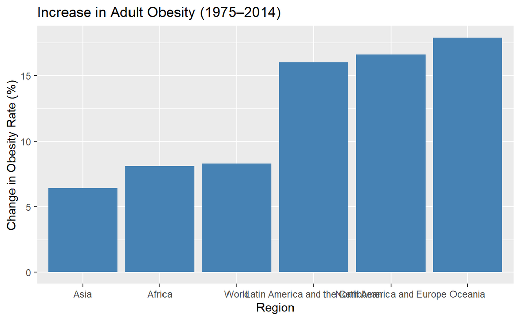

   ```r
      ggplot(obesity_change, aes(x = reorder(Entity, Change), y = Change)) +
     geom_col(fill = "steelblue") +
     labs(
   title = "Increase in Adult Obesity (1975–2014)",
   x = "Region",
   y = "Change in Obesity Rate (%)"
     )
   ```

6. Create a meaningful plot / figure with the dataset. Make sure to provide a figure caption (via the chunk options / Rmarkdown) and correctly label the figure.

## Final Note

Make sure to push all your commits and changes to GitHub before submitting the exercise sheet.